# Project: Identify Customer Segments

#### features associated with age

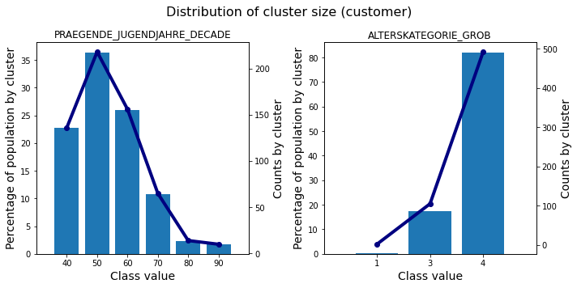

```python
feature_5_cluster_3 = customers_imputation_copy.loc[customers_imputation_copy["cluster"]==3, "PRAEGENDE_JUGENDJAHRE_DECADE"]
feature_6_cluster_3 = customers_imputation_copy.loc[customers_imputation_copy["cluster"]==3, "ALTERSKATEGORIE_GROB"]
fig, ax = plt.subplots(1,2, figsize=(10,5))

plot_cluster_distribution(feature_5_cluster_3, "customer", ax=ax[0], feature="PRAEGENDE_JUGENDJAHRE_DECADE", x_label="Class value")
plot_cluster_distribution(feature_6_cluster_3, "customer", ax=ax[1], feature="ALTERSKATEGORIE_GROB", x_label="Class value")
plt.tight_layout()
```

The disribution of cognate feature classes is very similar to the overrepresented cluster. Overall, we see a higher share of older individuals in both clusters.

#### features associated with personality traits

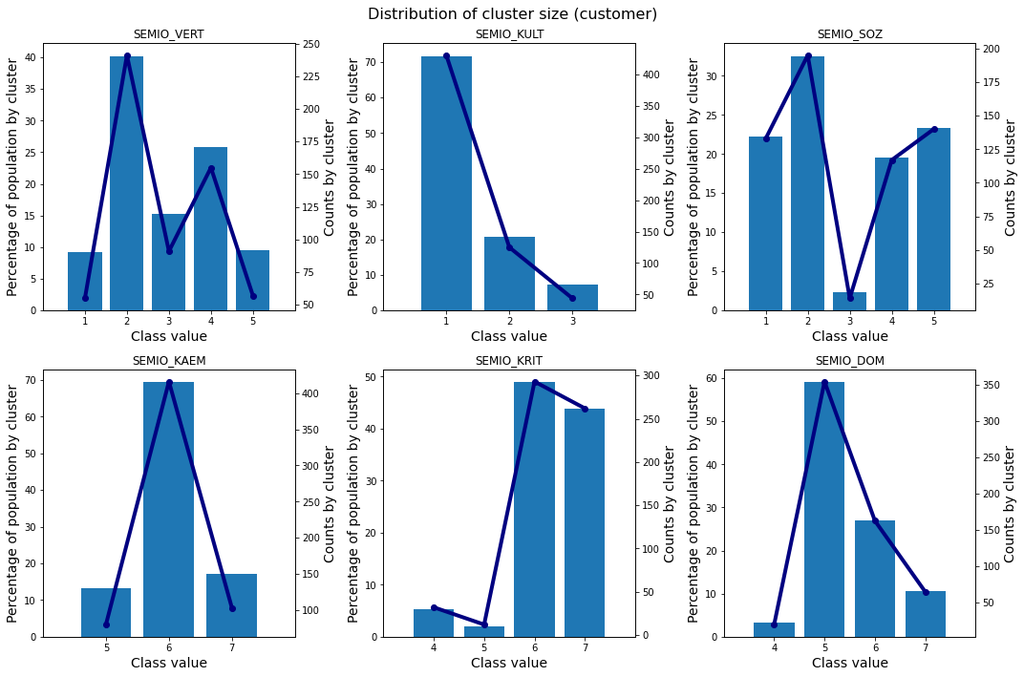

```python
feature_7_cluster_3 = customers_imputation_copy.loc[customers_imputation_copy["cluster"]==3, "SEMIO_VERT"]
feature_8_cluster_3 = customers_imputation_copy.loc[customers_imputation_copy["cluster"]==3, "SEMIO_KULT"]
feature_9_cluster_3 = customers_imputation_copy.loc[customers_imputation_copy["cluster"]==3, "SEMIO_SOZ"]

feature_10_cluster_3 = customers_imputation_copy.loc[customers_imputation_copy["cluster"]==3, "SEMIO_KAEM"]
feature_11_cluster_3 = customers_imputation_copy.loc[customers_imputation_copy["cluster"]==3, "SEMIO_KRIT"]
feature_12_cluster_3 = customers_imputation_copy.loc[customers_imputation_copy["cluster"]==3, "SEMIO_DOM"]

fig, ax = plt.subplots(2,3, figsize=(15,10))

plot_cluster_distribution(feature_7_cluster_3, "customer", ax=ax[0,0], feature="SEMIO_VERT", x_label="Class value")
plot_cluster_distribution(feature_8_cluster_3, "customer", ax=ax[0,1], feature="SEMIO_KULT", x_label="Class value")
plot_cluster_distribution(feature_9_cluster_3, "customer", ax=ax[0,2], feature="SEMIO_SOZ", x_label="Class value")
plot_cluster_distribution(feature_10_cluster_3, "customer", ax=ax[1,0], feature="SEMIO_KAEM", x_label="Class value")
plot_cluster_distribution(feature_11_cluster_3, "customer", ax=ax[1,1], feature="SEMIO_KRIT", x_label="Class value")
plot_cluster_distribution(feature_12_cluster_3, "customer", ax=ax[1,2], feature="SEMIO_DOM", x_label="Class value")
plt.tight_layout()
```

The results show that a high percentage of cluster 3 cohort indicated to be highly or very highly affiliation with the character traits dreamful (SEMIO_VERT; approx. > 65%), cultural-minded (SEMIO_KULT; 100%), socially-minded (SEMIO_SOZ; approx. 60%). In contrast, low or very low affiliation towards following character traits is attributed to the majority of the cluster 3 cohort. Combatitive attitude (SEMIO_KAEM; 100%), critical-minded (SEMIO_KRIT; approx. >90%) and dominant-minded (SEMIO_DOM; >90%)

### Discussion 3.3: Compare Customer Data to Demographics Data

Results from cluster analysis revealed some significant differences between the cohorts in the overrepresented cluster (cluster 0) versus the underrepresented cluster (cluster 3).

The dataset actually provides information on household wealth (CAMEO_INTL_2015_WEALTH) income status (HH_EINKOMMEN_SCORE) and the type/life stage (CAMEO_INTL_2015_LIFE) of corresponding residents. Let's check their distribution for both clusters.

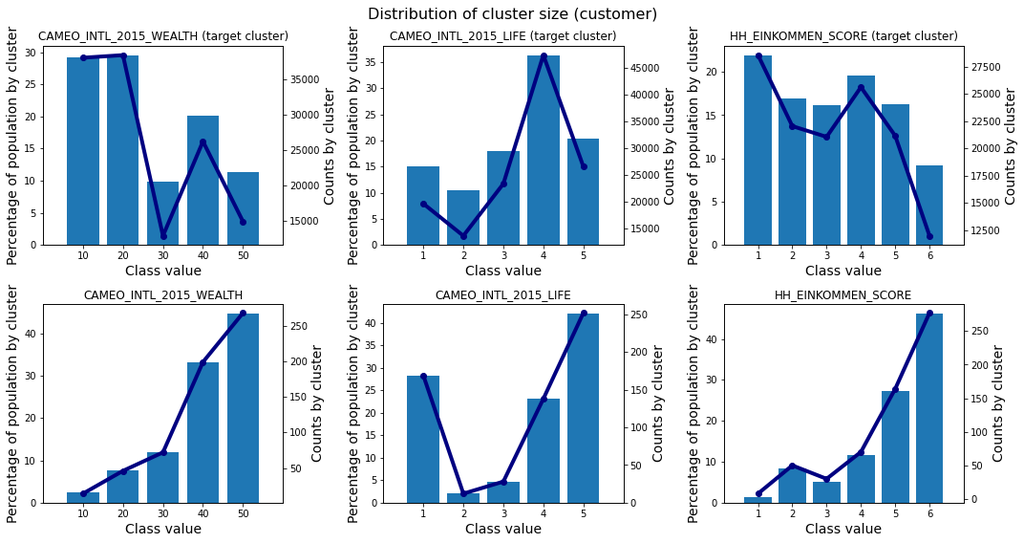

```python
feature_wealth_c0 = customers_imputation_copy.loc[customers_imputation_copy["cluster"]==0, "CAMEO_INTL_2015_WEALTH"]
feature_life_c0 = customers_imputation_copy.loc[customers_imputation_copy["cluster"]==0, "CAMEO_INTL_2015_LIFE"]
feature_inc_c0 = customers_imputation_copy.loc[customers_imputation_copy["cluster"]==0, "HH_EINKOMMEN_SCORE"]
feature_wealth_c3 = customers_imputation_copy.loc[customers_imputation_copy["cluster"]==3, "CAMEO_INTL_2015_WEALTH"]
feature_life_c3 = customers_imputation_copy.loc[customers_imputation_copy["cluster"]==3, "CAMEO_INTL_2015_LIFE"]
feature_inc_c3 = customers_imputation_copy.loc[customers_imputation_copy["cluster"]==3, "HH_EINKOMMEN_SCORE"]
fig, ax = plt.subplots(2,3, figsize=(15,8))

plot_cluster_distribution(feature_wealth_c0, "customer", ax=ax[0,0], feature="CAMEO_INTL_2015_WEALTH (target cluster)", x_label="Class value")
plot_cluster_distribution(feature_life_c0, "customer", ax=ax[0,1], feature="CAMEO_INTL_2015_LIFE (target cluster)", x_label="Class value")
plot_cluster_distribution(feature_inc_c0, "customer", ax=ax[0,2], feature="HH_EINKOMMEN_SCORE (target cluster)", x_label="Class value")
plot_cluster_distribution(feature_wealth_c3, "customer", ax=ax[1,0], feature="CAMEO_INTL_2015_WEALTH", x_label="Class value")
plot_cluster_distribution(feature_life_c3, "customer", ax=ax[1,1], feature="CAMEO_INTL_2015_LIFE", x_label="Class value")
plot_cluster_distribution(feature_inc_c3, "customer", ax=ax[1,2], feature="HH_EINKOMMEN_SCORE", x_label="Class value")
plt.tight_layout()
```

Wealth (CAMEO_INTL_2015_WEALTH) or household-income (HH_EINKOMMEN_SCORE) exhibits a markedly different distribution between the 2 clusters. The overrepresented cluster has a much higher share of wealthy housholds (>45% and >60% if including confortable households (class variable 3)). Also, >55% of the overrepresented cluster maps to high and very high income housholds (class variable 1,2,3), respectively. Including average income households, the percentage increases to almost 75%. This is in stark contrast to the underrepresented cluster, which consists of predominantly poor and low-income households (>75% in CAMEO_INTL_2015_WEALTH and HH_EINKOMMEN_SCORE). As such, these findings support the aforementioned hypothesis of income status being linked to type of residential area.  
If we look at the distribution for the life-stage feature (CAMEO_INTL_2015_LIFE) conditioned on cluster affiliation, we can see that older families/mature couples (class variable 4) and elderly people (class variable 5) account for the most share of each cluster, i.e. approx. 55% and 66% for the overrepresented and underrepresented cluster, respectively. As expected, this is in line with the distribution pattern for PRAEGENDE_JUGENDJAHRE_DECADE and ALTERKATEGORIE_GROB, both of which also reflect age of the underyling cluster population.  
This probably reflects the general demographic distribution for germany. The share of older people keeps growing for the past years and currenty the >40 years of age cohort makes up almost 57% of the total population, whereas the age group 18-39 only consists of approx. 27% (https://de.statista.com/statistik/daten/studie/1365/umfrage/bevoelkerung-deutschlands-nach-altersgruppen/). As such, the population is quite strongly skewed towards higher age. Consequently, we can expect a higher share of older people in both clusters. However, we can see some major differences with respect to age between the clusters. The overrepresented cluster has a much higher share of families with school age children and young couples with children. Nevertheless, age does not seem to be an explicitly good predictor for the company's target group.

Nevertheless, we see a significant difference in age distribution with almost the entire underrepresented cluster consisting of individuals of at least 46 years of age (approx. 80% of >60 years of age). In contrast, the >60 years of age cohort in cluster 0 (overrepresented cluster) represents only <50% of the total cluster population. So overall, the underrepresented cluster contains a higher share of older people.

It seems that mail-order company's major target segment comprises of the wealthy and high-income subpopulation. Based on this finding, I assume that we should also be able to see differences in neighborhod quality between the underlying cluster cohorts, i.e. expecting higher share of good and very good neighborhod quality, respectively, being associated with the overrepresented cluster. This would be of particular interest to better narrow down the target population, since neighborhood quality is clearly defined by applying standarized criteria (https://www.irap.ch/uploads/tx_hsrpm/Schlussbericht_Wohnumfeldqualitaet_2009_03.pdf). As such, this information could be used to explicitly target potential customers. Information on neighborhood quality is provided by the feature WOHNLAGE_QUALITY.

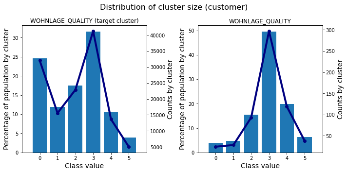

```python
feature_neigh_q_c0 = customers_imputation_copy.loc[customers_imputation_copy["cluster"]==0, "WOHNLAGE_QUALITY"]
feature_neigh_q_c3 = customers_imputation_copy.loc[customers_imputation_copy["cluster"]==3, "WOHNLAGE_QUALITY"]
fig, ax = plt.subplots(1,2, figsize=(10,5))

plot_cluster_distribution(feature_neigh_q_c0, "customer", ax=ax[0], feature="WOHNLAGE_QUALITY (target cluster)", x_label="Class value")
plot_cluster_distribution(feature_neigh_q_c3, "customer", ax=ax[1], feature="WOHNLAGE_QUALITY", x_label="Class value")
plt.tight_layout()
```

As depicted in the figure above, a high share of the target cluster (cluster 0) cohort is living in neighborhoods defined as very good (approx. 12% vs. approx. 5% in underrepresented cluster; class variable 1). Similarly, a much higher share of the underrepresented cluster subpopulation is living in poor quality neighborhoods (approx. 11% vs. approx. 20% in underrepresented cluster; class variable 4). It's not really clear to which type of neighborhood (higher vs. lower quality, respectively) class variable 0 ("no score calculated") can be attributed to.

Let's see if we can further narrrow down the target audience. Many studies show that online affinity positivly correlates with income/wealth at higher age but exhibits a negative correlation between income/wealth and younger age (https://www.fachmarktzentrum.de/marktteilnehmer/verbraucher/studie-regionale-onlineaffinitaet.html, https://www.regiodata.eu/de/news/1161-onlineaffinitaet-in-deutschland-was-steht-hinter-den-zahlen). Basically, high income older people having an inherently higher online affinity, which reflects the benefit of time-saving, whereas younger people that usually have lower income, are keen on finding saving opportunities and, thus, tend to exhibit increased only-affinity.  
Let's check if we see any difference in online affinity between both clusters (feature ONLINE_AFFINITAET).

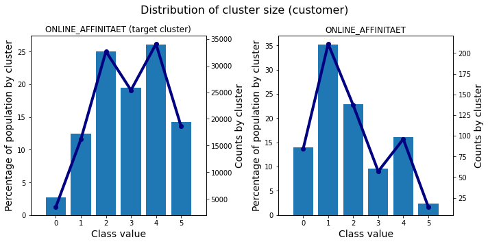

```python
feature_neigh_q_c0 = customers_imputation_copy.loc[customers_imputation_copy["cluster"]==0, "ONLINE_AFFINITAET"]
feature_neigh_q_c3 = customers_imputation_copy.loc[customers_imputation_copy["cluster"]==3, "ONLINE_AFFINITAET"]
fig, ax = plt.subplots(1,2, figsize=(10,5))

plot_cluster_distribution(feature_neigh_q_c0, "customer", ax=ax[0], feature="ONLINE_AFFINITAET (target cluster)", x_label="Class value")
plot_cluster_distribution(feature_neigh_q_c3, "customer", ax=ax[1], feature="ONLINE_AFFINITAET", x_label="Class value")
plt.tight_layout()
```

Again, we can see a markedly difference between both clusters, with the target cluster exhibiting >55% share of people indicating high/highest (class variable 3,4,5) online-affinity, whereas the same cohort makes up only >25% in the underepresented cluster. Maybe the online-affinity explains the higher share of younger people as well as the higher share of high-income people in the overrepresented cluster.

> Congratulations on making it this far in the project! Before you finish, make sure to check through the entire notebook from top to bottom to make sure that your analysis follows a logical flow and all of your findings are documented in **Discussion** cells. Once you've checked over all of your work, you should export the notebook as an HTML document to submit for evaluation. You can do this from the menu, navigating to **File -> Download as -> HTML (.html)**. You will submit both that document and this notebook for your project submission.